# Feature Engineering And Initial Modelling

Michał Pastuszka, Karol Saputa, Mateusz Bąkała

31 marca 2019

## Feature Engineering

### Imputation of NA’s

We continued our previous work, which was described previously in a report to be done with preprocessing data. To be fair, we processed missing values and identified important variables, but there was one thing still maybe not missing, but possible to be done. This thing was imputing missing values. So we ran the code below.

```r
treatment <- design_missingness_treatment(df_train, varlist = colnames(df_train)[-1])
df_train <- prepare(treatment, df_train)
df_test <- prepare(treatment, df_test)
df_tune <- prepare(treatment, df_tune)
```

With the help of invaluable vtreat library we managed to do this in a one-liner. It was so easy though thanks to our previous work on cleaning and analysing our datasets.

### Lack of opportunities to add variables

Having said “farewell” to our missing values just as Wokulski said it to Miss Izabela, we could move on to proper feature engineering. But, as we soon realized, not much work here could be done. First of all, this dataset is pretty minute and even very complicated models can be computed within highly reasonable time. Thus we had no interest in dropping columns, especially since every column COULD make a positive difference on our models’ performance.

Furthermore, no useful information could be added. It was too anonymous to make use of our abysmal knowledge of professional economics and we already added columns basing on type of missing values. That seemed to be about enough.

We almost went for binning one of our variables, but then we did some rapid checks and realized we won’t profit from it, we would just lose some data. For anyone interested it was supposed to be like this:

```r
cut(df_train$NetFractionInstallBurden, c(0, 25, 50, 80, 120, 1000))
```

All things considered, we realized that we had done most of this whole feature engineering thing before and now we could play a bit with our models.

## Modelling

### Setting up the scene

At this point we had a dataset shining like a diamond but if it was a diamond, it was definitely an unused one. So we blew the dust off the models we had in our model garage, waiting idly since like two days. Their engines was in a perfect state, though (barring one little incident which should sink forgotten in a dark abyss of silenced history, never to bother anyone anymore). A task was set up to support our approaching struggles.

```r
task <- makeClassifTask(id = "task", data = df_train, target = "RiskPerformance")
```

We wrote separate script for most of our learners… just to realize that they are all the same actually. The only piece of code we really need was a function like this below:

```r
run_learner <- function(lrn) {
  train_ <- train(lrn, task)
  prediction <- predict(train_, newdata = df_test)
  calculateROCMeasures(prediction) -> result
  calculateConfusionMatrix(prediction)
  score <- c(auc = measureAUC(prediction$data$prob.Good, truth = prediction$data$truth, positive = "Good"),
             acc = result$measures$acc)
  score
}
```

It was all nice and two-class classifications were waiting just around the corner, but we didn’t want to arrive unprepared, so we dummified our factors, courtesy to mlr package.

```r
df_train <- mlr::createDummyFeatures(df_train, target = "RiskPerformance")
df_test <- mlr::createDummyFeatures(df_test, target = "RiskPerformance")
df_tune <- mlr::createDummyFeatures(df_tune, target = "RiskPerformance")
```

### Actors entering the stage

We would love to run every existing model on our dataset, but some simply weren’t worthy being there. We also wanted to include models of different background and underlying idea. Last but not least, we preferred readily-working models to the troublesome ones.

With all this in minds we selected our lucky five. We suppose these may not be our final choices, but they would be amongst the best choices for the first stage of the Grand Modelling (trademarks here). Namely, these are:

- bartMachine,
- J48,
- LiblineaRL1LogReg,
- lssvm,
- randomForestSRC,
- xgboost.

Some may notice that this five constitutes of six models. That’s right, it’s just how we do things – we give 120% of ourselves to ensure best outcome possible.

### Actors doing art

We let our actors play their roles, we looked at critic reviews and were ready to sum it up just like that. But that would be too easy to do it this way. Instead, we asked ourselves one important question:

“What is the goal of our existence?”

Besides obvious answers like “wasting Earth resources” we came up with the essence of our work – it’s meant to replace human weaklings when computing a risk of a loan not being paid off. We made use of external risk estimate previously – so how would it work out if we compared performance on a dataset without external risk estimate and a dataset with this column only?

This idea was too good to pass on. We hastily computed more models to have necessary data and reminded ourselves that one picture would do more good than harm. As such, we include a nice plot to illustrate our incoming point.

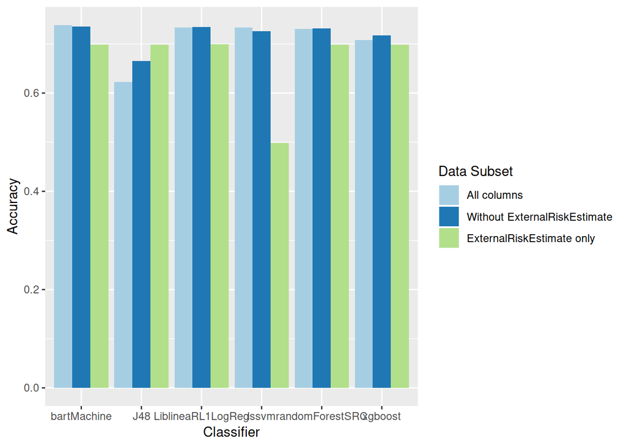

There are some nice results, some too-good-to-be-true and one we wholeheartedly disagree with. But, one after another.

### Critic reviews

Most of our chosen models show the tendency to do better without ExternalRiskEstimate than with just this one column. That suggests that our model might be inherently better than human work. Almost every model returned 70% of accuracy for “ExternalRiskEstimate only” and bad performance of lssvm should be considered as something abnormal and safely ignored.

Then we notice that, in general, deleting ExternalRiskEstimate did almost nothing to our models’ accuracy. Some lost, some gained, but never too dramatically. It seems like deleting this one variable wouldn’t hurt us, but more study is needed to confirm it’s indeed the case.

Then we arrive at our greatest hope, J48 model. It behaves very differently to other models, growing it’s accuracy as number of information is reduced. We already have plans of further study in this matter, as we expect J48 to get at least 72% accuracy on dataset with no columns (just the target). Then, given appropriate tuning, we might achieve a model guessing correct label three times out of four with no information necessary.

Did we mention that our data has about 50:50 proportion of “Good” and “Bad” risk performance instances?

## Drawing conclusions

We successfully got to the point of working models, but it’s too early yet to compare their performances. There is a lot to be gained through careful and sensible tuning, so most models still have the potential to come out on top. Even a new challenger may arise, given the fact that lssvm just isn’t reliable and we would need to fill the gap so that we wouldn’t drop to 100% engagement.